# 6_3_ResidualsAnalysis

```r
library(fpp3)
```

# References

1. Hyndman, R.J., & Athanasopoulos, G., 2021. *Forecasting: principles and practice*. 3rd edition.
2. Fable package documentation
- https://fable.tidyverts.org/index.html
- https://fable.tidyverts.org/articles/fable.html

# Libraries

```r
library(fpp3)
library(patchwork)
```

# Residuals diagnostics

In general, **for time series models** we are going to check **4 properties of the residuals**:

1. Autocorrelation of the residuals (information left on the residuals).
2. Zero mean of the residuals (bias of the forecasts).
3. Constant variance of the residuals (homoscedasticity).
4. Normal distribution of the residuals.

**1 and 2** are definitely more relevant when assessing the model. A model that does not satisfy them can be improved upon. Several methods may satisfy them and we may need to select among them.

**3 and 4** are useful to easily compute prediction intervals and to have prediction intervals that are not too wide.

- Apart from a box-cox transformation, there is usually little you can do to ensure the normality and heteroscedasticity of your residuals.
- There are alternative approaches to computing the prediction intervals (bootstrapping) that will allow us to produce confidence intervals even in these situations.

Please read carefully [section 5.4](https://otexts.com/fpp3/) of the book as well as the **pdf uploaded to blackboard**.

The properties above are general checkpoints for time series models. Some specific models (e.g linear models) will require that we do some additional checks on the residuals. We will see this in due course.

# Example 1

```r
bricks <- aus_production %>%
  filter_index("1970 Q1" ~ "2004 Q4") %>% # Shorthand for filtering data between 1970 and 2004
  select(Bricks)
```

Note that here we have fit more than one model in one fit:

```r
bricks_fit <- bricks %>% model(
                                Mean = MEAN(Bricks), #Fit two models at once
                                Nv = NAIVE(Bricks)
                               )

bricks_fit
```

```
# A mable: 1 x 2
     Mean      Nv
  <model> <model>
1  <MEAN> <NAIVE>
```

## MEAN model

```r
model_vals <- bricks_fit %>% augment()
```

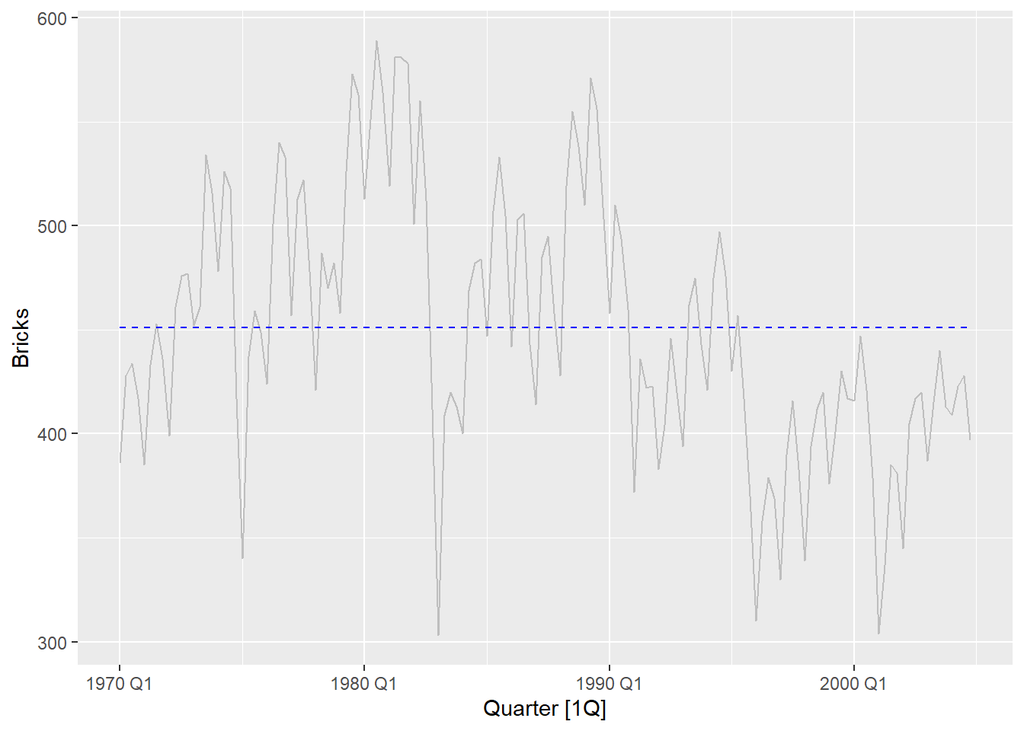

```r
model_vals %>%
  filter(.model == "Mean") %>%
  autoplot(Bricks, colour = "gray") +
  geom_line(aes(y=.fitted), colour = "blue", linetype = "dashed")
```

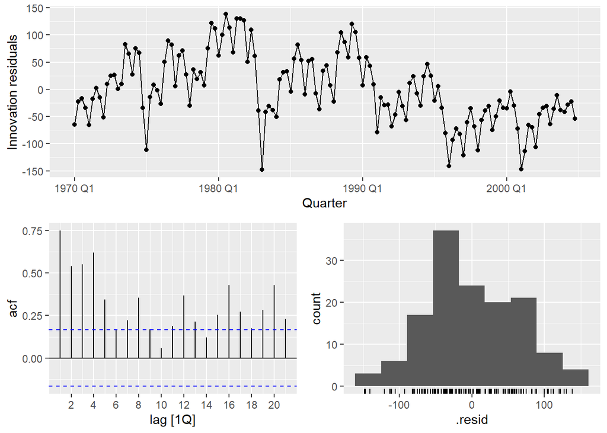

```r
bricks_fit %>%
  select(Mean) %>% # Selects the Mean model
  gg_tsresiduals()
```

```r
# Compute the mean of the residuals
model_vals %>% as_tibble() %>%
  filter(.model == "Mean") %>%
  summarise(mean = mean(.innov, na.rm = TRUE))
```

```
# A tibble: 1 × 1
       mean
      <dbl>
1 -4.86e-15
```

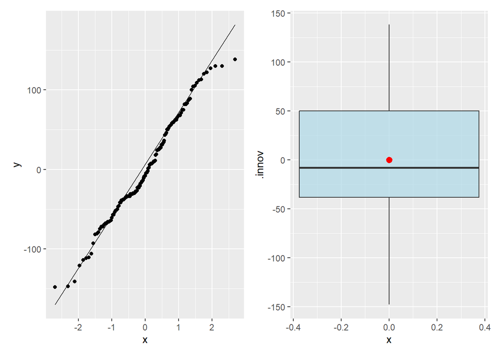

```r
mean_vals <- filter(model_vals, .model=="Mean")

# Generate qq_plot
p1 <- ggplot(mean_vals, aes(sample = .innov))
p1 <- p1 + stat_qq() + stat_qq_line()

# Generate box-plot
p2 <- ggplot(data = mean_vals, aes(y = .innov)) +
      geom_boxplot(fill="light blue", alpha = 0.7) +
      stat_summary(aes(x=0), fun="mean", colour= "red") # Include the mean

p1 + p2
```

1. The residuals are highly correlated, as the correlogram clearly shows (ACF values outside the dashed bounds)
- In this case this is clearly related to the simplicity of the model. The residuals look exactly like the time plot, only shifted by the mean of the time series.
- We are barely using information in the model. To fix this we would need to change the model.
2. The residuals have mean 0 (they are the series shifted by the mean of the series)
3. Visual inspection of the variance of the residuals across historical data indicates lack of homoscedasticity. There are recession periods (such as 1982 or 1974) where the variation of the series is much higher.
- NOTE: visual inspection is not a substitute for formal testing, but we will spare that for now.
4. Visual inspection agrees with the hypothesis that the residuals are fairly normal. The histogram seems relatively bell shaped and the distribution adjusts fairly well to the QQ-plot (except on the tails and perhaps a bit in the middle). The boxplot further confirms the relative symmetry of the distribution, showing as well that the mean is close to the median.
- To formally assess the normality we would need to perform a test, something we will not do for now.
- Understand that **the normality check is applied to the unordered set of residuals** (the frequency distribution of the residuals). We may have residuals that follow a normal distribution but that are arranged in a heteroscedastic manner.

## NAIVE model

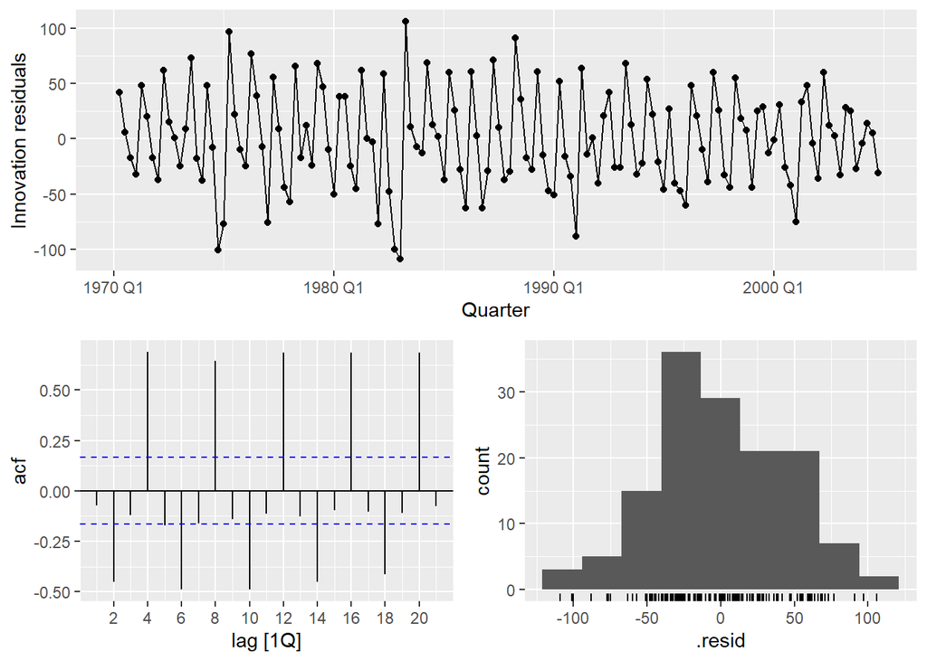

```r
bricks_fit %>%
  select(Nv) %>%
  gg_tsresiduals()
```

```r
# Compute the mean of the residuals
model_vals %>% as_tibble() %>%
  filter(.model == "Nv") %>%
  summarise(mean = mean(.innov, na.rm = TRUE))
```

```
# A tibble: 1 × 1
    mean
   <dbl>
1 0.0791
```

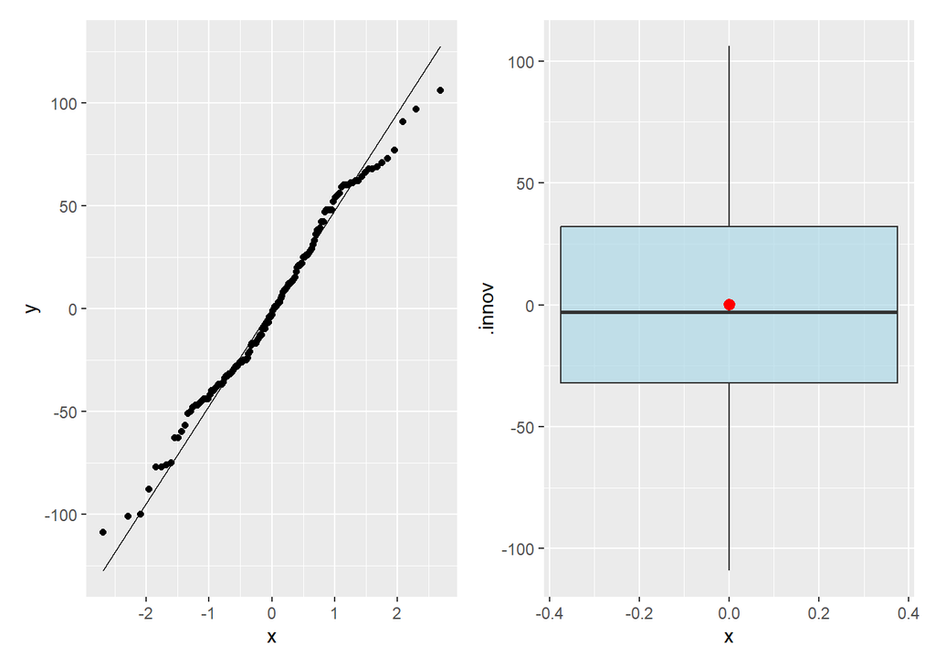

```r
mean_vals <- filter(model_vals, .model=="Nv")

# Generate qq_plot
p1 <- ggplot(mean_vals, aes(sample = .innov))
p1 <- p1 + stat_qq() + stat_qq_line()

# Generate box-plot
p2 <- ggplot(data = mean_vals, aes(y = .innov)) +
      geom_boxplot(fill="light blue", alpha = 0.7) +
      stat_summary(aes(x=0), fun="mean", colour= "red") # Include the mean

p1 + p2
```

1. The residuals are clearly correlated.
2. The innovation residuals mean is close to 0 (0.08). To formally assess if this difference is statistically significant we could perform a t-test.
3. These residuals are more homoscedastic than those of the mean model. The variance of the residuals remains more uniform across the historical data. The crisis in 1974 and 1982-83 could be treated as outliers.
- NOTE: visual inspection is not a substitute for formal testing, but we will spare that for now.
4. Visually the residuals seem to be normally distributed. The histogram seems symmetric and relatively bell-shaped. The values adjust well in the qq-plot with the exception of the tails. The box-plox confirms the symmetry of the distribution and the closeness of mean and median.
- To formally assess the normality we would need to perform a test, something we will not do for now.

# Example 2

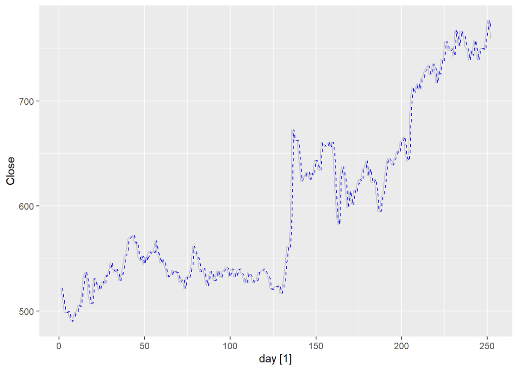

```r
# Re-index based on trading days
google_stock <- gafa_stock %>%
  filter(Symbol == "GOOG", year(Date) >= 2015) %>%
  mutate(day = row_number()) %>%
  update_tsibble(index = day, regular = TRUE)

# Filter the year of interest
google_2015 <- google_stock %>% filter(year(Date) == 2015)

# Fit the models
google_fit <- google_2015 %>%
  model(
    Mean = MEAN(Close),
    Naive = NAIVE(Close)
  )

# Extract values from the mable:
model_vals <- google_fit %>% augment()

# Plot fitted values for the NAIVE model:
model_vals %>%
  filter(.model == "Naive") %>%
  autoplot(Close, colour = "gray") +
  geom_line(aes(y=.fitted), colour = "blue", linetype = "dashed")
```

## NAIVE model

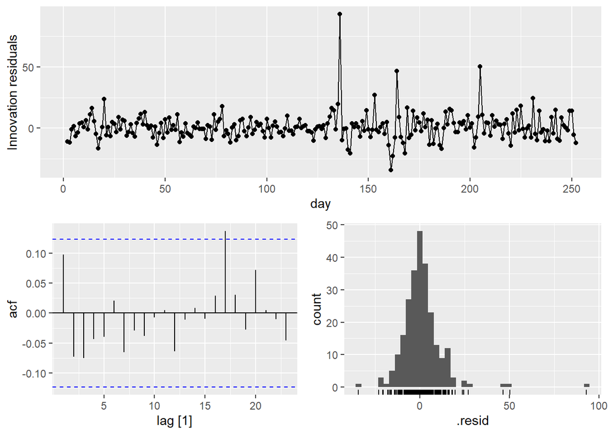

```r
google_fit %>%
  select(Naive) %>% # Selects the Mean model
  gg_tsresiduals()
```

```r
# Compute the mean of the residuals
model_vals %>% as_tibble() %>%
  filter(.model == "Naive") %>%
  summarise(mean = mean(.innov, na.rm = TRUE))
```

```
# A tibble: 1 × 1
   mean
  <dbl>
1 0.944
```

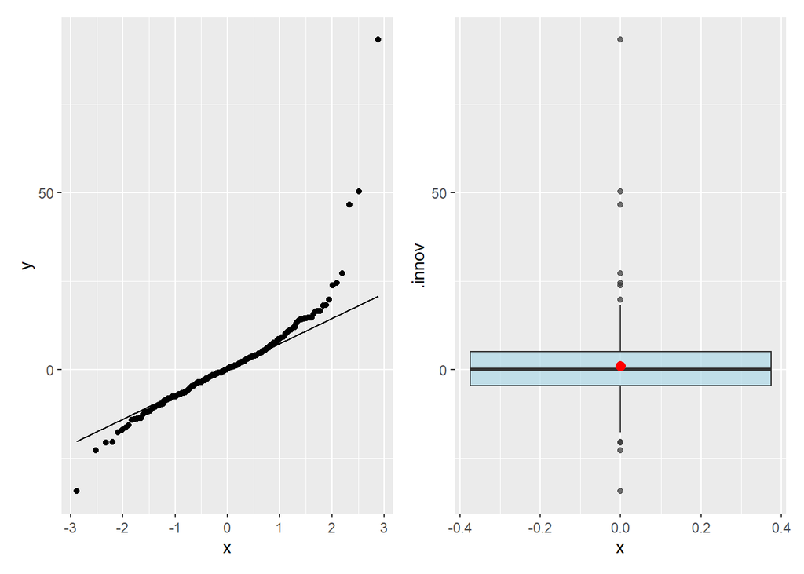

```r
mean_vals <- filter(model_vals, .model=="Naive")

# Generate qq_plot
p1 <- ggplot(mean_vals, aes(sample = .innov))
p1 <- p1 + stat_qq() + stat_qq_line()

# Generate box-plot
p2 <- ggplot(data = mean_vals, aes(y = .innov)) +
      geom_boxplot(fill="light blue", alpha = 0.7) +
      stat_summary(aes(x=0), fun="mean", colour= "red") # Include the mean

p1 + p2
```

## MEAN model

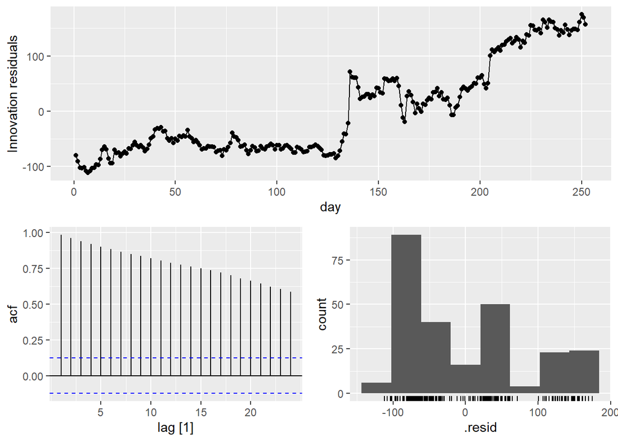

```r
google_fit %>%
  select(Mean) %>% # Selects the Mean model
  gg_tsresiduals()
```

```r
# Compute the mean of the residuals
model_vals %>% as_tibble() %>%
  filter(.model == "Mean") %>%
  summarise(mean = mean(.innov, na.rm = TRUE))
```

```
# A tibble: 1 × 1
      mean
     <dbl>
1 2.71e-14
```

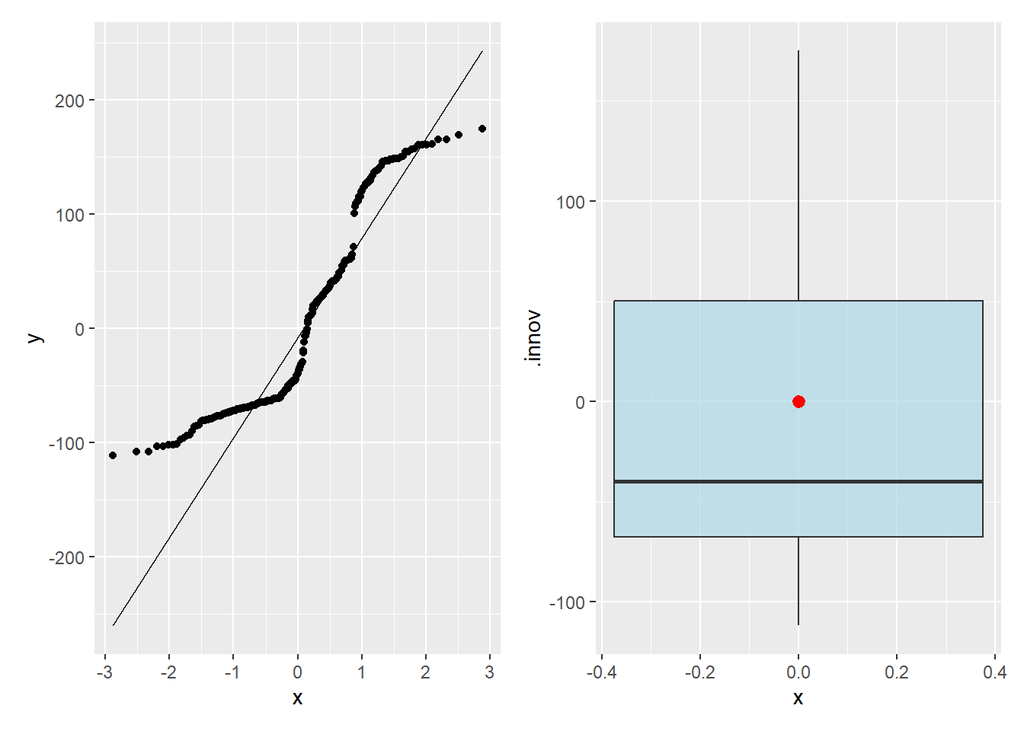

```r
mean_vals <- filter(model_vals, .model=="Mean")

# Generate qq_plot
p1 <- ggplot(mean_vals, aes(sample = .innov))
p1 <- p1 + stat_qq() + stat_qq_line()

# Generate box-plot
p2 <- ggplot(data = mean_vals, aes(y = .innov)) +
      geom_boxplot(fill="light blue", alpha = 0.7) +
      stat_summary(aes(x=0), fun="mean", colour= "red") # Include the mean

p1 + p2
```